# FAKE NEWS DETECTION

Business Question: In the today generation many companies/brands spreds false statements like they are hiring and increase there data base which lead candidate to get false information so candidate will get to know weither the information is correct or not and its companies to get awareness of getting correct information.

### Steps :

DataSet : https://www.kaggle.com/datasets/rajatkumar30/fake-news

# Importing the essential libraries

```python
import pandas as pd
import numpy as np
import matplotlib.pyplot as plt
import nltk
from nltk.corpus import stopwords
import string
import re
from gensim.models import Word2Vec
from sklearn.model_selection import train_test_split
from sklearn.ensemble import RandomForestClassifier
from sklearn.feature_extraction.text import TfidfVectorizer
from sklearn.metrics import classification_report
from sklearn.model_selection import train_test_split
from tensorflow.keras.models import Sequential
from tensorflow.keras.layers import Dense, Conv1D, MaxPooling1D, Flatten
from sklearn.ensemble import GradientBoostingClassifier
```

# Loading the data set

```python
dataset = pd.read_csv(r"C:/Users/Sahil Rathi/Desktop/fake news/archive/train (2).csv", sep=";")
```

# Preprocessing

**We do preporcessing for Optimization of performance: If processing a large dataset, consider optimizing by reusing compiled regex patterns:Train/Test/dupication/Validation/Split/stopword for removal of that we use this.**

```python
stopwords_en=stopwords.words('english')
ps_stemmer=nltk.PorterStemmer()

def clean_text(text):

    clean_text=text.lower()
    clean_text=re.sub('\W+',' ',clean_text)
    clean_text=re.sub('\s+',' ',clean_text)
    clean_text=clean_text.split(' ')
    clean_text=[word for word in clean_text if word not in stopwords_en+['']]
    clean_text=[ps_stemmer.stem(word) for word in clean_text]
    clean_text=' '.join(clean_text)

    return clean_text
```

**to performs text cleaning operations such as removing stopwords, lowercasing, removing special characters, etc.**

```python
dataset['title_text']=dataset['title']+dataset['text']
dataset['clean_text']=dataset['title_text'].apply(clean_text)
dataset['text_length']=dataset['title_text'].apply(lambda x:len(x))
dataset['word_count']=dataset['title_text'].apply(lambda x:len(x.split(' ')))
dataset['text_punctuations_percentage']=dataset['title_text'].apply(lambda x : len([a for a in x if a in string.punctuation])/len(x))
dataset['label']=dataset['label'].replace({'FAKE':0,'REAL':1})
dataset.head()
```

|  | Unnamed: 0 | title | text | label | title_text | clean_text | text_length | word_count | text_punctuations_percentage |
| --- | --- | --- | --- | --- | --- | --- | --- | --- | --- |
| 0 | 0 | Palestinians switch off Christmas lights in Be... | RAMALLAH, West Bank (Reuters) - Palestinians s... | 1 | Palestinians switch off Christmas lights in Be... | palestinian switch christma light bethlehem an... | 1410 | 228 | 0.019858 |
| 1 | 1 | China says Trump call with Taiwan president wo... | BEIJING (Reuters) - U.S. President-elect Donal... | 1 | China says Trump call with Taiwan president wo... | china say trump call taiwan presid chang islan... | 445 | 70 | 0.031461 |
| 2 | 2 | FAIL! The Trump Organization’s Credit Score W... | While the controversy over Trump s personal ta... | 0 | FAIL! The Trump Organization’s Credit Score W... | fail trump organ credit score make laughwhil c... | 2136 | 367 | 0.020131 |
| 3 | 3 | Zimbabwe military chief's China trip was norma... | BEIJING (Reuters) - A trip to Beijing last wee... | 1 | Zimbabwe military chief's China trip was norma... | zimbabw militari chief china trip normal visit... | 2759 | 449 | 0.017035 |
| 4 | 4 | THE MOST UNCOURAGEOUS PRESIDENT EVER Receives ... | There has never been a more UNCOURAGEOUS perso... | 0 | THE MOST UNCOURAGEOUS PRESIDENT EVER Receives ... | uncourag presid ever receiv courag award proce... | 2049 | 328 | 0.016105 |

**how the lengths of text differ between "REAL" and "FAKE" labeled articles. This analysis helps identify whether text length is a distinguishing feature for these labels**

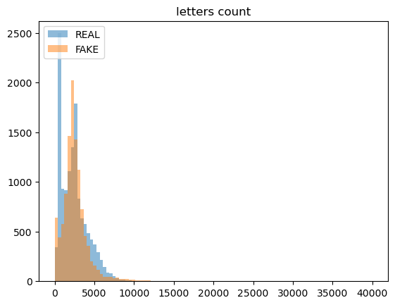

```python
plt.hist(dataset[dataset['label']==1]['text_length'],bins=np.linspace(0,40000,100),alpha=0.5,label='REAL')
plt.hist(dataset[dataset['label']==0]['text_length'],bins=np.linspace(0,40000,100),alpha=0.5,label='FAKE')
plt.title('letters count')
plt.legend(loc='upper left')
plt.show()
```

**i Used this code examines whether the number of words in articles (as measured by the word_count column) differs between the "REAL" and "FAKE"**

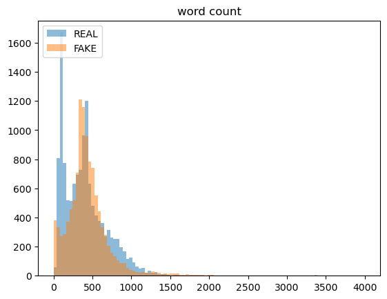

```python
plt.hist(dataset[dataset['label']==1]['word_count'],bins=np.linspace(0,4000,100),alpha=0.5,label='REAL')
plt.hist(dataset[dataset['label']==0]['word_count'],bins=np.linspace(0,4000,100),alpha=0.5,label='FAKE')
plt.title('word count')
plt.legend(loc='upper left')
plt.show()
```

**If you observe that "FAKE" articles consistently use fewer punctuation marks than "REAL" ones, punctuation percentage could be a strong feature for distinguishing the two classes in a machine learning model**

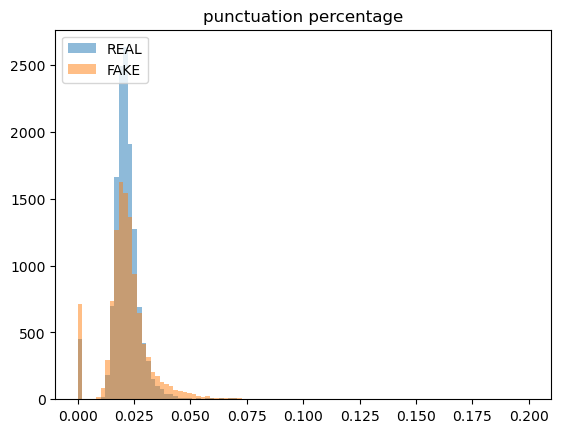

```python
plt.hist(dataset[dataset['label']==1]['text_punctuations_percentage'],bins=np.linspace(0,0.2,100),alpha=0.5,label='REAL')
plt.hist(dataset[dataset['label']==0]['text_punctuations_percentage'],bins=np.linspace(0,0.2,100),alpha=0.5,label='FAKE')
plt.legend(loc='upper left')
plt.title('punctuation percentage')
plt.show()
```

## Vectorization

**Vectorization is the process of converting textual data (unstructured data) into numerical representations that machine learning and deep learning models can understand. Since ML models work with numbers, text data must be transformed into a numerical format.** TF-IDF is an abbreviation for Term Frequency Inverse Document Frequency. This is very common algorithm to transform text into a meaningful representation of numbers which is used to fit machine algorithm for prediction.

```python
def w2v_vectorize(corpus,vector_size=100,model=None):
    features = []
    if model==None:
        model=Word2Vec(corpus,vector_size=vector_size,seed=42)
    for tokens in corpus:
        zero_vector = np.zeros(model.vector_size)
        vectors = []
        for token in tokens.split(' '):
            if token in model.wv:
                try:
                    vectors.append(model.wv[token])
                except KeyError:
                    continue
        if vectors:
            vectors = np.asarray(vectors)
            avg_vec = vectors.mean(axis=0)
            features.append(avg_vec)
        else:
            features.append(zero_vector)
    return model,features

def tfidf_vectorizor(corpus,vector_size=100,model=None):
    if model ==None:
        model=TfidfVectorizer(max_features=vector_size)
    model=model.fit(corpus)
    tf_vector=model.transform(corpus)
    return model,tf_vector

w2v_model,w2v_vector=w2v_vectorize(dataset['clean_text'],vector_size=300)
tf_model,tfidf_vector=tfidf_vectorizor(dataset['clean_text'],vector_size=300)
tfidf_vector.shape
```

```
(24353, 300)
```

**Since word_count and text_punctuations_percentage might have different scales compared to the TF-IDF features, consider standardizing or normalizing the numerical features**

```python
X=pd.DataFrame(tfidf_vector.toarray())
X['word_count']=dataset['word_count']
X['text_punctuations_percentage']=dataset['text_punctuations_percentage']
Y=dataset['label']
X.columns = X.columns.astype(str)
```

**Train the Model**

```python
X_train,X_test,y_train,y_test=train_test_split(X,Y,test_size=0.1,random_state=42)
```

**Use the Model GradientBoosting Classifier**

```python
rfc=GradientBoostingClassifier()
rfc=rfc.fit(X_train,y_train)
pred=rfc.predict(X_test)
print(classification_report(y_test,pred))
```

```
              precision    recall  f1-score   support

           0       0.95      0.99      0.97      1069
           1       0.99      0.96      0.97      1367

    accuracy                           0.97      2436
   macro avg       0.97      0.97      0.97      2436
weighted avg       0.97      0.97      0.97      2436
```

**Use the Model RandomForestClassifier**

```python
rfc=RandomForestClassifier()
rfc=rfc.fit(X_train,y_train)
pred=rfc.predict(X_test)
print(classification_report(y_test,pred))
```

```
              precision    recall  f1-score   support

           0       0.95      0.99      0.97      1069
           1       0.99      0.96      0.98      1367

    accuracy                           0.97      2436
   macro avg       0.97      0.97      0.97      2436
weighted avg       0.97      0.97      0.97      2436
```

**For reshaping the data intio 1D CNN and also created 1D CNN with five layer so that we can achive binary classification**

```python
X_train = np.reshape(X_train, (X_train.shape[0], X_train.shape[1], 1))
X_test = np.reshape(X_test, (X_test.shape[0], X_test.shape[1], 1))

model = Sequential()
model.add(Conv1D(filters=64, kernel_size=3, activation='relu', input_shape=(302, 1)))
model.add(MaxPooling1D(pool_size=2))
model.add(Conv1D(filters=128, kernel_size=3, activation='relu'))
model.add(MaxPooling1D(pool_size=2))
model.add(Conv1D(filters=256, kernel_size=3, activation='relu'))
model.add(MaxPooling1D(pool_size=2))
model.add(Flatten())
model.add(Dense(128, activation='relu'))
model.add(Dense(64, activation='relu'))
model.add(Dense(1, activation='sigmoid'))

model.compile(optimizer='adam', loss='binary_crossentropy', metrics=['accuracy'])
model.fit(X_train, y_train, epochs=5, batch_size=32, validation_data=(X_test, y_test))
```

```
<keras.callbacks.History at 0x220d13dcfd0>
```

**the model tries to minimize the error or cost How you evaluate the model's performance during training and testing**

```python
pred=model.predict(X_test)
accuracy = model.evaluate(X_test, y_test)
print(f'Test Accuracy: {accuracy[1] * 100:.2f}%')
```

```
Test Accuracy: 96.55%
```

FOR NEWS CHANNEL AND COMPANIES WHERE MARKET CORRECT INFORMATION IS REQUIRED

**Recommendations: and Area of Improvement** Model Optimization: Experiment with different regularization techniques to further improve generalization. Alternative Models: Consider using other models such as logistic regresion or XGBoost for potentially better performance on more complex datasets.